# TezGüncel (1)

**INTRODUCTION**

In this project we focused on predicting customer churn in the telecommuncations industry using the Telco Customer Churn dataset from Kaggle. Customer churn is a significant challenge for telecom providers because keeping existing customers is more cost-effective than getting new ones. The aim is to build machine learning models that can detect-prone customers and support retention strategies.

DATASET

```python
#Importing Libraries
import pandas as pd
import numpy as np
import matplotlib.pyplot as plt
import os
import seaborn as sns
import missingno as msno
from IPython.display import display
from scipy.stats import chi2_contingency
from sklearn.model_selection import train_test_split
from sklearn.compose import ColumnTransformer
from sklearn.preprocessing import OneHotEncoder, StandardScaler
from sklearn.impute import SimpleImputer
from sklearn.pipeline import Pipeline
from sklearn import __version__ as skl_ver
from sklearn.pipeline import Pipeline
from sklearn.metrics import (
    accuracy_score, precision_score, recall_score, f1_score,
    roc_auc_score, average_precision_score, confusion_matrix,
    roc_curve, precision_recall_curve
)

from sklearn.dummy import DummyClassifier
from sklearn.linear_model import LogisticRegression
from sklearn.tree import DecisionTreeClassifier
from sklearn.ensemble import RandomForestClassifier, GradientBoostingClassifier
from xgboost import XGBClassifier
import joblib
import warnings; warnings.filterwarnings("ignore", category=FutureWarning)
```

```python
#Importing the dataset which is chosen for the thesis
dfm=pd.read_csv("/content/WA_Fn-UseC_-Telco-Customer-Churn.csv")
dfm.head()
```

|  | customerID | gender | SeniorCitizen | Partner | Dependents | tenure | PhoneService | MultipleLines | InternetService | OnlineSecurity | ... | DeviceProtection | TechSupport | StreamingTV | StreamingMovies | Contract | PaperlessBilling | PaymentMethod | MonthlyCharges | TotalCharges | Churn |
| --- | --- | --- | --- | --- | --- | --- | --- | --- | --- | --- | --- | --- | --- | --- | --- | --- | --- | --- | --- | --- | --- |
| 0 | 7590-VHVEG | Female | 0 | Yes | No | 1 | No | No phone service | DSL | No | ... | No | No | No | No | Month-to-month | Yes | Electronic check | 29.85 | 29.85 | No |
| 1 | 5575-GNVDE | Male | 0 | No | No | 34 | Yes | No | DSL | Yes | ... | Yes | No | No | No | One year | No | Mailed check | 56.95 | 1889.5 | No |
| 2 | 3668-QPYBK | Male | 0 | No | No | 2 | Yes | No | DSL | Yes | ... | No | No | No | No | Month-to-month | Yes | Mailed check | 53.85 | 108.15 | Yes |
| 3 | 7795-CFOCW | Male | 0 | No | No | 45 | No | No phone service | DSL | Yes | ... | Yes | Yes | No | No | One year | No | Bank transfer (automatic) | 42.30 | 1840.75 | No |
| 4 | 9237-HQITU | Female | 0 | No | No | 2 | Yes | No | Fiber optic | No | ... | No | No | No | No | Month-to-month | Yes | Electronic check | 70.70 | 151.65 | Yes |

5 rows × 21 columns

```python
dfm.info()
```

```
<class 'pandas.core.frame.DataFrame'>
RangeIndex: 7043 entries, 0 to 7042
Data columns (total 21 columns):
 #   Column            Non-Null Count  Dtype
---  ------            --------------  -----
 0   customerID        7043 non-null   object
 1   gender            7043 non-null   object
 2   SeniorCitizen     7043 non-null   int64
 3   Partner           7043 non-null   object
 4   Dependents        7043 non-null   object
 5   tenure            7043 non-null   int64
 6   PhoneService      7043 non-null   object
 7   MultipleLines     7043 non-null   object
 8   InternetService   7043 non-null   object
 9   OnlineSecurity    7043 non-null   object
 10  OnlineBackup      7043 non-null   object
 11  DeviceProtection  7043 non-null   object
 12  TechSupport       7043 non-null   object
 13  StreamingTV       7043 non-null   object
 14  StreamingMovies   7043 non-null   object
 15  Contract          7043 non-null   object
 16  PaperlessBilling  7043 non-null   object
 17  PaymentMethod     7043 non-null   object
 18  MonthlyCharges    7043 non-null   float64
 19  TotalCharges      7043 non-null   object
 20  Churn             7043 non-null   object
dtypes: float64(1), int64(2), object(18)
memory usage: 1.1+ MB
```

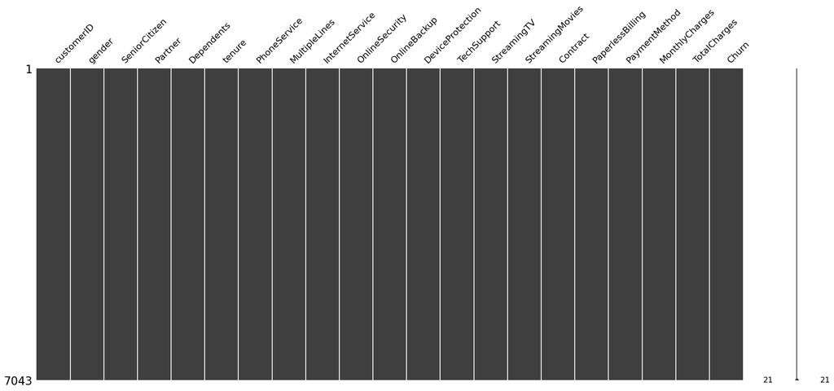

```python
#Column and Row Examination
msno.matrix(dfm)
```

```python
dfm.describe()
```

|  | SeniorCitizen | tenure | MonthlyCharges |
| --- | --- | --- | --- |
| count | 7043.000000 | 7043.000000 | 7043.000000 |
| mean | 0.162147 | 32.371149 | 64.761692 |
| std | 0.368612 | 24.559481 | 30.090047 |
| min | 0.000000 | 0.000000 | 18.250000 |
| 25% | 0.000000 | 9.000000 | 35.500000 |
| 50% | 0.000000 | 29.000000 | 70.350000 |
| 75% | 0.000000 | 55.000000 | 89.850000 |
| max | 1.000000 | 72.000000 | 118.750000 |

```python
dfm.isnull().sum()
```

|  | 0 |
| --- | --- |
| customerID | 0 |
| gender | 0 |
| SeniorCitizen | 0 |
| Partner | 0 |
| Dependents | 0 |
| tenure | 0 |
| PhoneService | 0 |
| MultipleLines | 0 |
| InternetService | 0 |
| OnlineSecurity | 0 |
| OnlineBackup | 0 |
| DeviceProtection | 0 |
| TechSupport | 0 |
| StreamingTV | 0 |
| StreamingMovies | 0 |
| Contract | 0 |
| PaperlessBilling | 0 |
| PaymentMethod | 0 |
| MonthlyCharges | 0 |
| TotalCharges | 0 |
| Churn | 0 |

**dtype:** int64

**DATA CLEANING**

```python
#Column Normalization - Columns were edited
COL_ALIASES = {
    "churn": "Churn",
    "gender": "gender",
    "age": "age",
    "customerage": "age",
    "seniorcitizen": "SeniorCitizen",
    "partner": "Partner",
    "dependents": "Dependents",
    "internetservice": "InternetService",
    "internet": "InternetService",
    "phoneservice": "PhoneService",
    "phone": "PhoneService",
    "onlinesecurity": "OnlineSecurity",
    "security": "OnlineSecurity",
    "techsupport": "TechSupport",
    "technicalsupport": "TechSupport",
    "streamingtv": "StreamingTV",
    "streamingmovies": "StreamingMovies",
    "contract": "Contract",
    "tenure": "tenure",
    "tenuremonths": "tenure",
    "servicetime": "tenure",
    "servicemonths": "tenure",
    "paymentmethod": "PaymentMethod",
    "payment": "PaymentMethod",
    "monthlycharges": "MonthlyCharges",
    "monthlycharge": "MonthlyCharges",
    "monthly_fee": "MonthlyCharges",
    "monthlyfees": "MonthlyCharges",
    "totalcharges": "TotalCharges",
    "totalcharge": "TotalCharges",
    "total_fee": "TotalCharges",
    "totalfees": "TotalCharges",
    "totalbill": "TotalCharges",
}
ren = {}
for c in dfm.columns:
    key = c.lower().strip()
    if key in COL_ALIASES:
        ren[c] = COL_ALIASES[key]
dfm.rename(columns=ren, inplace=True)
```

```python
#string cleanup and category standardization
#remove spaces in object columns
for c in dfm.select_dtypes(include="object").columns:
    dfm[c] = dfm[c].astype(str).str.strip()


yn_cols = [c for c in ["Churn","Partner","Dependents","PhoneService",
                       "OnlineSecurity","TechSupport","StreamingTV","StreamingMovies"]
           if c in dfm.columns]
for c in yn_cols:
    dfm[c] = dfm[c].replace({"yes":"Yes","no":"No","Y":"Yes","N":"No","nan":"", "None":""})

# InternetService
if "InternetService" in dfm.columns:
    dfm["InternetService"] = dfm["InternetService"].replace({
        "Fiber": "Fiber optic", "fiber": "Fiber optic",
        "No internet service": "No", "No Internet": "No", "None": "No"
    })

# Contract
if "Contract" in dfm.columns:
    dfm["Contract"] = dfm["Contract"].replace({
        "Month to month":"Month-to-month", "Month-to-Month":"Month-to-month",
        "One Year":"One year", "Two Year":"Two year"
    })
```

```python
#Numerical cleanings were done
num_cols = [c for c in ["MonthlyCharges","TotalCharges","tenure","age"] if c in dfm.columns]
for c in num_cols:
    dfm[c] = pd.to_numeric(dfm[c], errors="coerce")

if "tenure" in dfm.columns:
    dfm.loc[dfm["tenure"] < 0, "tenure"] = np.nan
if "MonthlyCharges" in dfm.columns:
    dfm.loc[dfm["MonthlyCharges"] < 0, "MonthlyCharges"] = np.nan
if "TotalCharges" in dfm.columns:
    dfm.loc[dfm["TotalCharges"] < 0, "TotalCharges"] = np.nan
```

```python
#Target encoding and minimal NA usage
if "Churn" in dfm.columns:
    if dfm["Churn"].dtype == "O":
        dfm["Churn01"] = dfm["Churn"].map({"Yes":1, "No":0, "1":1, "0":0})
    else:
        dfm["Churn01"] = dfm["Churn"].astype(float)
else:
    dfm["Churn01"] = np.nan

# droping rows without target
dfm = dfm[~dfm["Churn01"].isna()].copy()
```

```python
#Feature engineering before EDA
#If there is no real age, a proxy of age from the Senior Citizen
if "age" not in dfm.columns and "SeniorCitizen" in dfm.columns:
    dfm["SeniorCitizen"] = pd.to_numeric(dfm["SeniorCitizen"], errors="coerce").fillna(0).astype(int)
    dfm["AgeGroupProxy"] = dfm["SeniorCitizen"].map({0:"<65", 1:"65+"})
elif "age" in dfm.columns:
    bins = [0,25,35,45,55,65,120]
    labels = ["<25","25–34","35–44","45–54","55–64","65+"]
    dfm["AgeGroupProxy"] = pd.cut(dfm["age"], bins=bins, labels=labels, include_lowest=True)

#Category orders
if "InternetService" in dfm.columns:
    dfm["InternetService"] = pd.Categorical(dfm["InternetService"],
                                            categories=["No","DSL","Fiber optic"], ordered=True)
if "Contract" in dfm.columns:
    dfm["Contract"] = pd.Categorical(dfm["Contract"],
                                     categories=["Month-to-month","One year","Two year"], ordered=True)
```

```python
#Quick data quality report
report = {
    "rows": len(dfm),
    "cols": len(dfm.columns),
    "na_rate(Churn01)": float(dfm["Churn01"].isna().mean()) if "Churn01" in dfm.columns else None,
    "na_rate(MonthlyCharges)": float(dfm["MonthlyCharges"].isna().mean()) if "MonthlyCharges" in dfm.columns else None,
    "na_rate(TotalCharges)": float(dfm["TotalCharges"].isna().mean()) if "TotalCharges" in dfm.columns else None,
    "na_rate(tenure)": float(dfm["tenure"].isna().mean()) if "tenure" in dfm.columns else None,
}
print(report)
```

```
{'rows': 7043, 'cols': 23, 'na_rate(Churn01)': 0.0, 'na_rate(MonthlyCharges)': 0.0, 'na_rate(TotalCharges)': 0.001561834445548772, 'na_rate(tenure)': 0.0}
```

**EDA**

We followed these paths in the eda phase: Demographics: Senior citizens and single-person households churn more often.

Services: Customers with fiber optic internet and those without online security or tech support have the highest churn.

Contracts: Month-to-month contracts show extremely high churn (~43%), while long-term contracts strongly reduce churn.

Billing: Customers paying by electronic check churn the most (~45%).

These findings align with previous research and provide useful business insights.

```python
#EDA
import matplotlib.pyplot as plt
import numpy as np
import pandas as pd

#the pallets we will use
PALETTES = {
    "neutral": ["#4C78A8"],
    "rainbow": ["#4C78A8","#F58518","#E45756","#72B7B2","#54A24B","#EECA3B","#B279A2"],
    "cool":    ["#3B8CCC","#86B6E2","#C7DBF0"],
    "warm":    ["#F1696C","#F59D7A","#F7C59F"],
    "qual":    ["#4C78A8","#F58518","#E45756","#72B7B2","#54A24B","#EECA3B","#B279A2","#FF9DA6"],
    "internet": ["#8F8F8F","#4C78A8","#E45756"],          # No / DSL / Fiber optic
    "contract": ["#E45756","#F58518","#54A24B"],          # Month-to-month / One / Two year
    "payment":  ["#E45756","#4C78A8","#54A24B","#B279A2","#F58518","#72B7B2"]
}

def _apply_colors(ax, n, palette):
    pal = PALETTES.get(palette, PALETTES["neutral"])
    colors = (pal * (n // len(pal) + 1))[:n]
    for bar, c in zip(ax.patches, colors):
        bar.set_color(c)

def plot_rate_by_category(data, category, title, order=None, rot=0, figsize=(6.6,4.6), palette="neutral"):
    if category not in data.columns:
        print(f"[Skip] {category}"); return
    tmp = (data.dropna(subset=[category])
              .groupby(category, dropna=False)["Churn01"].mean().reset_index())
    if tmp.empty:
        print(f"[Skip] {category} empty"); return
    if order is not None:
        tmp[category] = pd.Categorical(tmp[category], categories=order, ordered=True)
        tmp = tmp.sort_values(category)
    else:
        tmp = tmp.sort_values("Churn01", ascending=False)

    fig, ax = plt.subplots(figsize=figsize)
    ax.bar(tmp[category].astype(str), (tmp["Churn01"]*100))
    _apply_colors(ax, len(tmp), palette)
    for i, v in enumerate(tmp["Churn01"]*100):
        ax.text(i, v+0.6, f"{v:.1f}%", ha="center", va="bottom", fontsize=9)
    ax.set_title(title); ax.set_ylabel("Churn rate (%)"); ax.set_xlabel(category)
    plt.xticks(rotation=rot)
    plt.tight_layout(); plt.show()

def plot_rate_vs_numeric(data, num_col, bins=10, title=None, figsize=(6.8,4.6), line_color="#4C78A8"):
    if num_col not in data.columns:
        print(f"[Skip] {num_col}"); return
    d = data[[num_col,"Churn01"]].dropna().copy()
    if d.empty:
        print(f"[Skip] {num_col} empty"); return
    try:
        q = np.quantile(d[num_col], np.linspace(0,1,bins+1))
        q = np.unique(q)
        if len(q) < 3:
            d["bin"] = pd.qcut(d[num_col], q=bins, duplicates="drop")
        else:
            d["bin"] = pd.cut(d[num_col], bins=q, include_lowest=True)
    except Exception:
        d["bin"] = pd.qcut(d[num_col], q=bins, duplicates="drop")
    grp = d.groupby("bin")["Churn01"].mean().reset_index()
    x, y = grp["bin"].astype(str), grp["Churn01"]*100

    fig, ax = plt.subplots(figsize=figsize)
    ax.plot(range(len(x)), y, marker="o", linewidth=2, color=line_color)
    ax.set_xticks(range(len(x))); ax.set_xticklabels(x, rotation=60, ha="right")
    ax.set_ylabel("Churn rate (%)"); ax.set_title(title or f"Churn rate vs {num_col}")
    plt.tight_layout(); plt.show()

def corr_heatmap(df_, cols, title="Correlation heatmap", cmap="coolwarm", annot=True, figsize=(6.4,5.2)):
    use = [c for c in cols if c in df_.columns]
    if len(use) < 3:
        print(f"[Skip] not enough cols: {use}"); return
    d = df_[use].dropna().copy()
    if d.empty:
        print("[Skip] no rows after NaN drop"); return
    c = d.corr(numeric_only=True)

    fig, ax = plt.subplots(figsize=figsize)
    im = ax.imshow(c, interpolation="nearest", cmap=cmap)
    ax.set_title(title)
    fig.colorbar(im, fraction=0.046, pad=0.04)
    ax.set_xticks(range(len(c.columns))); ax.set_xticklabels(c.columns, rotation=45, ha="right")
    ax.set_yticks(range(len(c.index))); ax.set_yticklabels(c.index)
    if annot:
        for i in range(c.shape[0]):
            for j in range(c.shape[1]):
                ax.text(j, i, f"{c.values[i,j]:.2f}", ha="center", va="center", fontsize=8, color="black")
    plt.tight_layout(); plt.show()
```

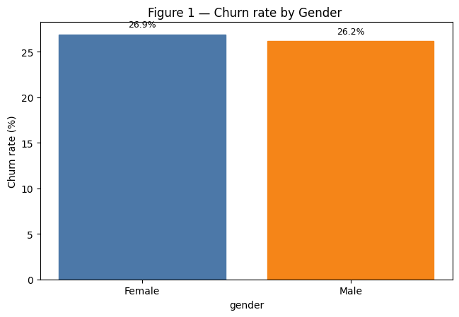

```python
#Gender comparison
plot_rate_by_category(dfm, "gender",
                      title="Figure 1 — Churn rate by Gender ",
                      palette="rainbow")
```

In this graph, Churn rate is 26.9 % for females and 26.2 for males. It demonstrates that gender does not have a big impact on churn.

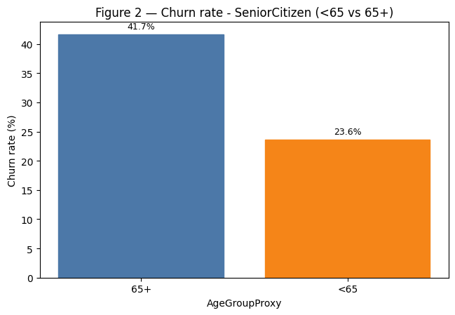

```python
# Figure 2: age groups
if "AgeGroupProxy" in dfm.columns and dfm["AgeGroupProxy"].notna().any():
    plot_rate_by_category(dfm, "AgeGroupProxy",
                          title="Figure 2 — Churn rate - SeniorCitizen (<65 vs 65+)",
                          palette="rainbow")
```

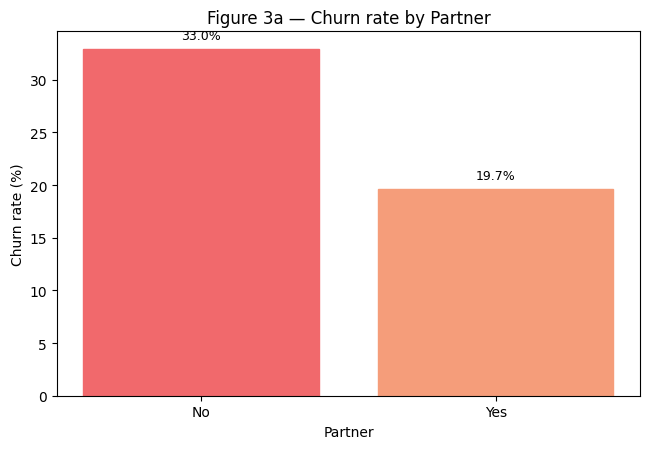

```python
# Figure 3a partner Yes/No
plot_rate_by_category(dfm, "Partner",
                      title="Figure 3a — Churn rate by Partner",
                      palette="warm")
```

Figure 3a demonstrates that churn rate is 33.0 % for customers without a partner and 19.7 % for those with a partner, which means that having a partner is linked to lower churn.

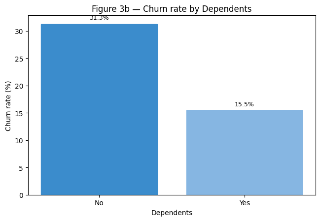

```python
# Figure 3b \ Dependents
plot_rate_by_category(dfm, "Dependents",
                      title="Figure 3b — Churn rate by Dependents",
                      palette="cool")
```

In this figure, churn rate by dependents is analyzed. The churn rate is 31.3% for customers without dependents and 15.5% for those with dependents. This means that customers with dependents are less likely to churn.

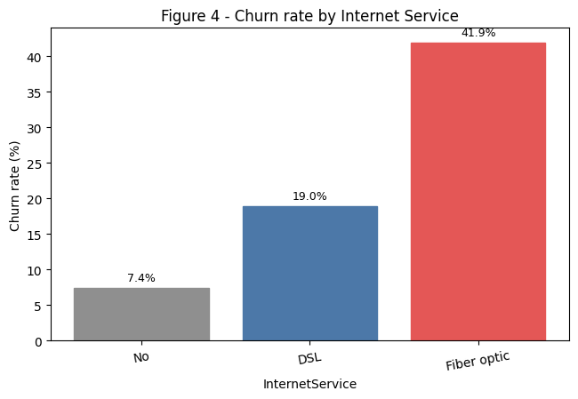

```python
# Figure 4: Churn rate by Internet Service (No/DSL/Fiber)
order_internet = ["No","DSL","Fiber optic"] if "InternetService" in dfm.columns else None
plot_rate_by_category(dfm, "InternetService",
                      title="Figure 4 - Churn rate by Internet Service",
                      order=order_internet, rot=10, palette="internet")
```

This graph shows that the churn rate is extremely high for fiber optic customers at 41.9%, which is compared to 19.0% for DSL and only 7.4% for people without internet.

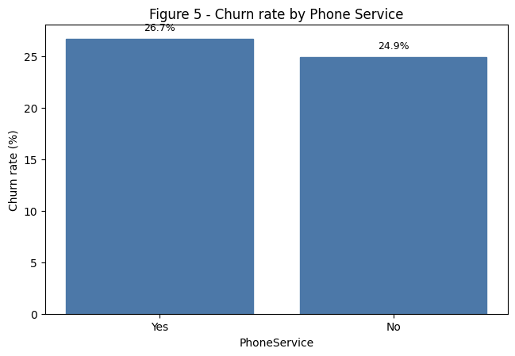

```python
# Figure 5: Phone Service
plot_rate_by_category(dfm, "PhoneService",
                      title="Figure 5 - Churn rate by Phone Service",
                      palette="neutral")
```

Figure 5 highlights that the churn rate is 26.7% for customers with phone service and 24.9% for those without. There is only a small difference between them, which means that phone service does not have a strong effect on churn

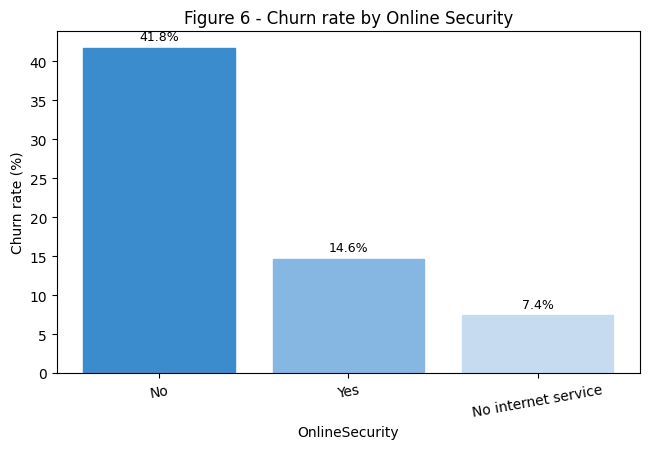

```python
# Figure 6: Online Security
plot_rate_by_category(dfm, "OnlineSecurity",
                      title="Figure 6 - Churn rate by Online Security",
                      rot=10, palette="cool")
```

Figure 6 shows the churn rate by online security. Customers without online security have a very high churn rate of 41.8%, while those with online security churn much less at 14.6%. Customers without internet service have the lowest churn at 7.4%. This means that offering online security is linked to lower churn.

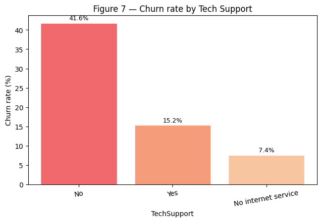

```python
# Figure 7 churn rate by Tech Support - Yes\No\CustomersNotTakingService
plot_rate_by_category(dfm, "TechSupport",
                      title="Figure 7 — Churn rate by Tech Support",
                      rot=10, palette="warm")
```

Figure 7 is about Churn rate by Tech Support, emphasize that customers without tech support have the highest churn rate at 41.6%, while those with tech support churn much more less at 15.2%. Customers without internet service have the lowest churn at 7.4%. This demonstrates that offering tech support helps to reduce churn.

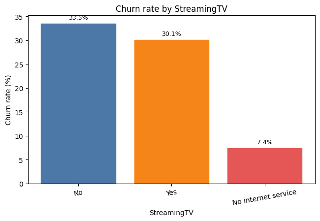

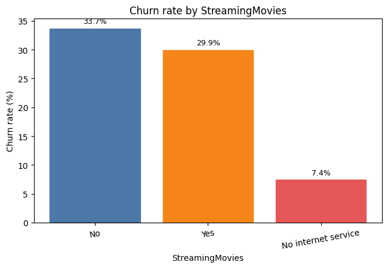

```python
# Churn rate by streaming
for col, ttl in [
    ("StreamingTV", "Churn rate by StreamingTV"),
    ("StreamingMovies", "Churn rate by StreamingMovies")
]:
    if col in dfm.columns:
        plot_rate_by_category(dfm, col, ttl, rot=10, palette="qual")
```

Figure shows the churn rate by Streaming Movies. Customers without Streaming Movies have a churn rate of 33.7%, while those with Streaming Movies churn at 29.9%. Customers without internet service have the lowest churn at 7.4%, and the small difference between Yes and No shows that Streaming Movies has little effect on churn. And also Straming TV is also similar to Streaming Movies. The churn rate s for Streaming Movies are also very close between customers with and without the service, which shows that these features have little impact on churn.

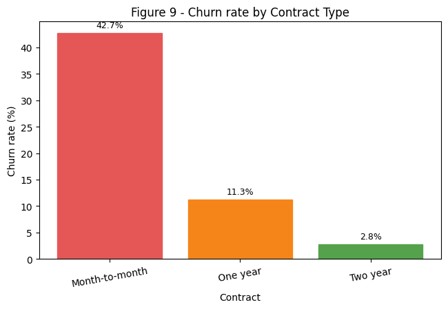

```python
# Figure 9 - churn rate by contract Type
order_contract = ["Month-to-month","One year","Two year"] if "Contract" in dfm.columns else None
plot_rate_by_category(dfm, "Contract",
                      title="Figure 9 - Churn rate by Contract Type",
                      order=order_contract, rot=10, palette="contract")
```

Figure 9 shows the churn rate by contract type. The difference is absolutely remarkable. “Customers with month-to-month contracts have a high churn rate, which is 42.7%, while those with one-year contracts churn much less, and two-year contracts have an extremely low churn rate.

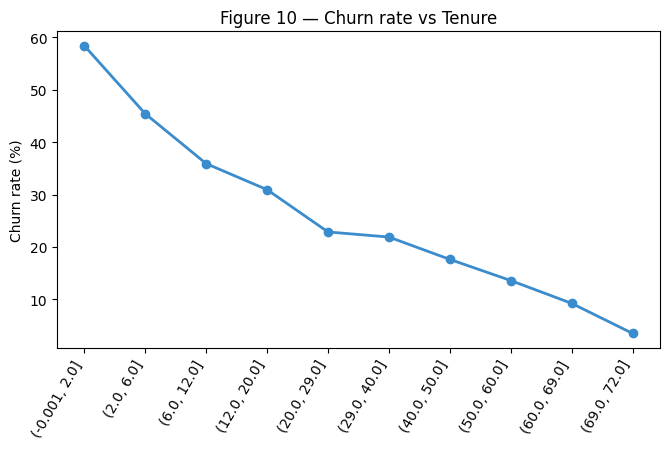

```python
# Figure churn rate by Tenure
plot_rate_vs_numeric(dfm, "tenure", bins=10,
                     title="Figure 10 — Churn rate vs Tenure",
                     line_color="#3B8CCC")
```

“Figure 10 shows the churn rate by tenure. Customers with very short tenure have the highest churn, which is close to 60%, while the rate decreases consistently as tenure increases. This demonstrates that long-term customers are much less likely to churn.

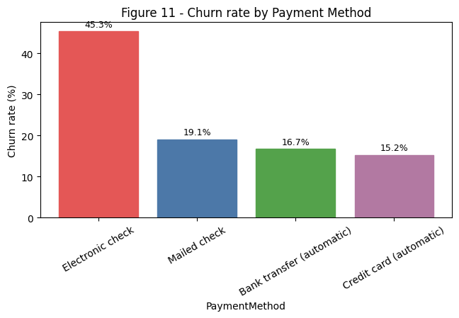

```python
# Figure 11: Churn  Rate by Payment Method
order_pm = None
if "PaymentMethod" in dfm.columns:
    uniq = dfm["PaymentMethod"].dropna().unique().tolist()
    if "Electronic check" in uniq:
        order_pm = ["Electronic check"] + [x for x in uniq if x != "Electronic check"]
plot_rate_by_category(dfm, "PaymentMethod",
                      title="Figure 11 - Churn rate by Payment Method",
                      order=order_pm, rot=30, palette="payment")
```

Figure 11 shows the churn rate by payment method. Customers paying by electronic check have the highest churn rate, which is 45.3%, while churn is much lower for mailed checks (19.1%), bank transfer (16.7%), and credit card payments (15.2%). This indicates that automatic payment methods help reduce churn.

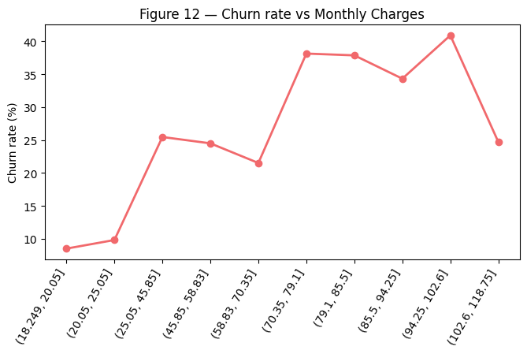

```python
# Figure 12: Churn Rate by Monthly Charges
plot_rate_vs_numeric(dfm, "MonthlyCharges", bins=10,
                     title="Figure 12 — Churn rate vs Monthly Charges",
                     line_color="#F1696C")
```

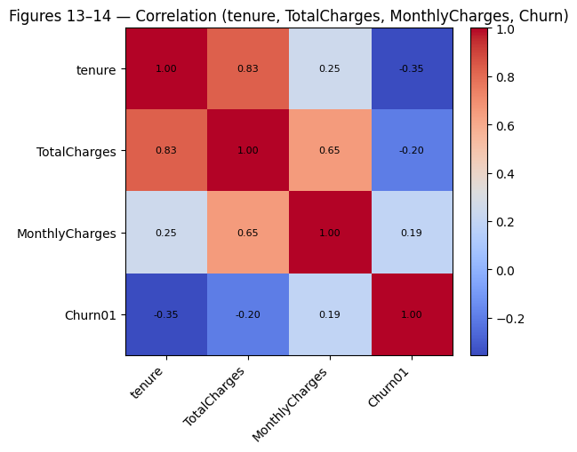

```python
# Figures 13–14: Correlation heatmap
corr_cols = [c for c in ["tenure","TotalCharges","MonthlyCharges","Churn01"] if c in dfm.columns]
corr_heatmap(dfm, corr_cols,
             title="Figures 13–14 — Correlation (tenure, TotalCharges, MonthlyCharges, Churn)",
             cmap="coolwarm", annot=True)
```

The heatmap shows strong positive correlation between tenure and total charges, and a negative correlation between tenure and churn. Monthly charges are positively related to churn.

```python
try:
    from statsmodels.stats.outliers_influence import variance_inflation_factor
    import statsmodels.api as sm
except Exception as e:
    print("VIF için statsmodels gerekli. Gerekirse: !pip install -q statsmodels")
    raise e

num_cols3 = dfm.select_dtypes(include=["int64","float64"]).columns.tolist()
X_num = dfm[num_cols3].copy().fillna(dfm[num_cols3].median())
X_num = sm.add_constant(X_num)

vif_rows = []
for i, col in enumerate(X_num.columns):
    if col == "const":
        continue
    vif = variance_inflation_factor(X_num.values, i)
    vif_rows.append({"feature": col, "VIF": round(vif, 3)})
display(pd.DataFrame(vif_rows).sort_values("VIF", ascending=False))
```

|  | feature | VIF |
| --- | --- | --- |
| 3 | TotalCharges | 9.600 |
| 1 | tenure | 5.803 |
| 2 | MonthlyCharges | 3.553 |
| 4 | Churn01 | 1.303 |
| 0 | SeniorCitizen | 1.066 |

The VIF table shows that TotalCharges (9.6) and tenure (5.8) have the highest multicollinearity, while other features are within acceptable levels.

PREPROCESSING

Missing values were imputed (median for numeric, most frequent for categorical).

Categorical variables were transformed using One-Hot Encoding (handle_unknown="ignore").

Two preprocessing pipelines were created:

```python
!pip -q install imbalanced-learn xgboost shap
```

```python
RANDOM_STATE = 42
np.random.seed(RANDOM_STATE)
```

```python
#Data split and column types - Yes - No
X = dfm.drop(columns=["Churn", "Churn01", "customerID"], errors="ignore")
y = dfm["Churn"].map({"No":0, "Yes":1}).astype(int)
assert "Churn01" not in X.columns, "Leakage: 'Churn01' features içinde!"
assert "Churn"  not in X.columns,  "Leakage: 'Churn' features içinde!"


X_train, X_test, y_train, y_test = train_test_split(
    X, y, test_size=0.20, stratify=y, random_state=RANDOM_STATE
)

num_cols = X_train.select_dtypes(include=[np.number]).columns.tolist()
cat_cols = [c for c in X_train.columns if c not in num_cols]
print(f"num={len(num_cols)}, cat={len(cat_cols)}")
```

```
num=4, cat=16
```

```python
#Preprocessing
try:
    OHE = OneHotEncoder(handle_unknown="ignore", sparse_output=False)  #>=1.2
except TypeError:
    OHE = OneHotEncoder(handle_unknown="ignore", sparse=False)         #<1.2

pre_lr = ColumnTransformer([
    ("num", Pipeline([("imp", SimpleImputer(strategy="median")),
                      ("sc",  StandardScaler(with_mean=True))]), num_cols),
    ("cat", Pipeline([("imp", SimpleImputer(strategy="most_frequent")),
                      ("oh",  OHE)]), cat_cols),
])

pre_tree = ColumnTransformer([
    ("num", SimpleImputer(strategy="median"), num_cols),
    ("cat", Pipeline([("imp", SimpleImputer(strategy="most_frequent")),
                      ("oh",  OHE)]), cat_cols),
])
```

Numeric features are imputed (median) and scaled; categorical features are imputed (most frequent) and one-hot encoded with handle_unknown='ignore'. For tree models we skip scaling, but keep imputation and one-hot encoding.

```python
#Train models such as Dummy, LR, RF, XGB printing metrics (ACC, PREC, REC, F1, ROC-AUC, PR-AP)

def print_metrics(y_true, proba, label, thr=0.5):
    pred = (proba >= thr).astype(int)
    ACC  = accuracy_score(y_true, pred)
    PREC = precision_score(y_true, pred, zero_division=0)
    REC  = recall_score(y_true, pred, zero_division=0)
    F1   = f1_score(y_true, pred, zero_division=0)
    AUC  = roc_auc_score(y_true, proba)
    AP   = average_precision_score(y_true, proba)
    print(f"{label} | ACC={ACC:.3f} PREC={PREC:.3f} REC={REC:.3f} F1={F1:.3f}  ROC-AUC={AUC:.3f} PR-AP={AP:.3f}")
    return {"label":label,"acc":ACC,"prec":PREC,"rec":REC,"f1":F1,"auc":AUC,"ap":AP}

# Class imbalance (XGB)
pos = y_train.sum(); neg = len(y_train) - pos
spw = (neg / pos) if pos else 1.0

# Dummy
pipe_dummy = Pipeline([("pre", pre_tree), ("clf", DummyClassifier(strategy="stratified", random_state=RANDOM_STATE))])
pipe_dummy.fit(X_train, y_train); proba_dummy = pipe_dummy.predict_proba(X_test)[:,1]
res_dummy = print_metrics(y_test, proba_dummy, "Dummy")

# Logistic Regression
pipe_lr = Pipeline([("pre", pre_lr),
                    ("clf", LogisticRegression(max_iter=1000, class_weight="balanced",
                                               solver="liblinear", random_state=RANDOM_STATE))])
pipe_lr.fit(X_train, y_train); proba_lr = pipe_lr.predict_proba(X_test)[:,1]
res_lr = print_metrics(y_test, proba_lr, "LR")

# Random Forest
pipe_rf = Pipeline([("pre", pre_tree),
                    ("clf", RandomForestClassifier(n_estimators=400, class_weight="balanced_subsample",
                                                  n_jobs=-1, random_state=RANDOM_STATE))])
pipe_rf.fit(X_train, y_train); proba_rf = pipe_rf.predict_proba(X_test)[:,1]
res_rf = print_metrics(y_test, proba_rf, "RF")

# XGBoost
pipe_xgb = Pipeline([("pre", pre_tree),
                     ("clf", XGBClassifier(n_estimators=500, learning_rate=0.05, max_depth=4,
                                           subsample=0.8, colsample_bytree=0.8,
                                           objective="binary:logistic", eval_metric="logloss",
                                           n_jobs=-1, random_state=RANDOM_STATE,
                                           scale_pos_weight=spw))])
pipe_xgb.fit(X_train, y_train); proba_xgb = pipe_xgb.predict_proba(X_test)[:,1]
res_xgb = print_metrics(y_test, proba_xgb, "XGB")
```

```
Dummy | ACC=0.622 PREC=0.289 REC=0.291 F1=0.290  ROC-AUC=0.516 PR-AP=0.272
LR | ACC=0.738 PREC=0.504 REC=0.783 F1=0.614  ROC-AUC=0.841 PR-AP=0.633
RF | ACC=0.786 PREC=0.627 REC=0.481 F1=0.545  ROC-AUC=0.823 PR-AP=0.611
XGB | ACC=0.762 PREC=0.537 REC=0.749 F1=0.626  ROC-AUC=0.835 PR-AP=0.649
```

```python
# Results \ Table
results = pd.DataFrame([res_dummy, res_lr, res_rf, res_xgb])[
    ["label","acc","prec","rec","f1","auc","ap"]
].sort_values("auc", ascending=False).reset_index(drop=True)
print("\n Summary : sorted by ROC-AUC) ")
print(results.round(3))
```

```
 Summary : sorted by ROC-AUC)
   label    acc   prec    rec     f1    auc     ap
0     LR  0.738  0.504  0.783  0.614  0.841  0.633
1    XGB  0.762  0.537  0.749  0.626  0.835  0.649
2     RF  0.786  0.627  0.481  0.545  0.823  0.611
3  Dummy  0.622  0.289  0.291  0.290  0.516  0.272
```

We trained several models and sorted results by ROC-AUC. Logistic Regression (balanced) achieved the best ROC-AUC (0.841), followed by XGBoost (0.835) and Random Forest (0.823); the Dummy baseline is near chance (0.516).

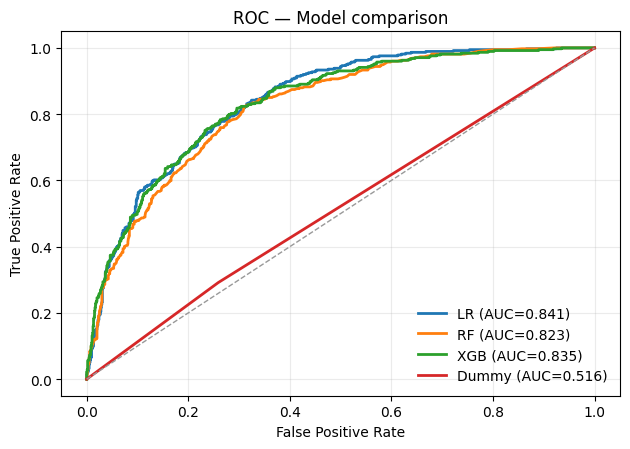

```python
#Model development comparison by ROC
probas = {"LR": proba_lr, "RF": proba_rf, "XGB": proba_xgb, "Dummy": proba_dummy}

plt.figure(figsize=(6.4,4.6))
for name, p in probas.items():
    fpr, tpr, _ = roc_curve(y_test, p)
    auc = roc_auc_score(y_test, p)
    plt.plot(fpr, tpr, lw=2, label=f"{name} (AUC={auc:.3f})")
plt.plot([0,1],[0,1],'--',lw=1,color='#999')
plt.xlabel("False Positive Rate"); plt.ylabel("True Positive Rate")
plt.title("ROC — Model comparison"); plt.legend(frameon=False); plt.grid(alpha=.25)
plt.tight_layout(); plt.show()
```

All models outperform the random baseline. The ROC curves show LR has the highest AUC, with XGB close behind and RF slightly lower.

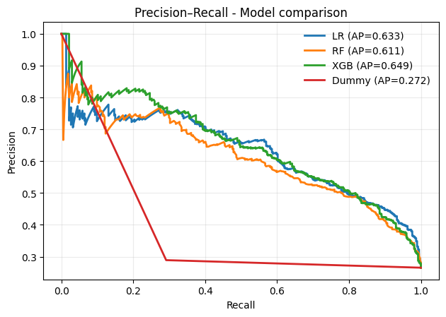

```python
# S7 — Model comparison by Precision recall
plt.figure(figsize=(6.4,4.6))
for name, p in probas.items():
    pr, rc, _ = precision_recall_curve(y_test, p)
    ap = average_precision_score(y_test, p)
    plt.plot(rc, pr, lw=2, label=f"{name} (AP={ap:.3f})")
plt.xlabel("Recall"); plt.ylabel("Precision")
plt.title("Precision–Recall - Model comparison"); plt.legend(frameon=False); plt.grid(alpha=.25)
plt.tight_layout(); plt.show()
```

With class imbalance, PR curves are more informative: XGB has the highest average precision (0.649), LR is close (0.633), and RF follows (0.611), all well above the Dummy baseline (0.272).

```python
# Confusion Matrix applying Best model thr=0.5)
best_label = results.iloc[0]["label"]
proba_map = {"LR (balanced)": proba_lr, "RF (balanced_subsample)": proba_rf,
             "XGB (spw)": proba_xgb, "Dummy": proba_dummy}
proba_best = proba_map.get(best_label, None)

if proba_best is not None:
    pred = (proba_best >= 0.5).astype(int)
    cm = confusion_matrix(y_test, pred)
    plt.figure(figsize=(4.4,3.8))
    plt.imshow(cm, cmap="Blues")
    for i in range(2):
        for j in range(2):
            plt.text(j, i, cm[i,j], ha="center", va="center")
    plt.xticks([0,1],["Pred 0","Pred 1"]); plt.yticks([0,1],["True 0","True 1"])
    plt.title(f"Confusion — {best_label} (thr=0.5)")
    plt.tight_layout(); plt.show()
else:
    print("Best model is not found.")
```

[output not shown]

```
Best model is not found.
```

```python
#Precision/Recall vs Threshold (Best model)
if proba_best is not None:
    ths = np.linspace(0.05, 0.95, 19)
    precs, recs = [], []
    for t in ths:
        pred = (proba_best >= t).astype(int)
        precs.append(precision_score(y_test, pred, zero_division=0))
        recs.append(recall_score(y_test, pred))
    plt.figure(figsize=(6.4,4.4))
    plt.plot(ths, precs, marker="o", label="Precision", lw=2)
    plt.plot(ths, recs,  marker="o", label="Recall",    lw=2)
    plt.xlabel("Threshold"); plt.ylabel("Score"); plt.title(f"Precision/Recall vs Threshold — {best_label}")
    plt.legend(frameon=False); plt.grid(alpha=.25); plt.tight_layout(); plt.show()
```

Results | Model Comparison

Logistic Regression (balanced): Highest ROC-AUC (0.841) → best interpretability.

Random Forest: Solid baseline (AUC 0.823), but below LR and XGB.

Conclusion